# (Factors that reflect on the profit for movies)

## by (Hend Zayed)

## Investigation Overview

> In this investigation, I wanted to look at the characteristics of movies that could be used to predict their profit. The main focus was on profit,releaed years ,budget and geners of movies: comdey ,darama ,thrill .. also investigating the most directors, production companies and actors who received the highest percentage of profits in their work

## Dataset Overview

> This document explores a dataset from TMDB .This data set contains information about 10,000 movies collected from The Movie Database (TMDb) that contain information about ( budget-revenue-original_title-cast homepage-director tagline -overview-runtime-genres-production_companies-release_date-vote_count-vote_average-release_year-budget_adj-revenue_adj). The Movie Database (TMDb) during the years 1960 to 2015

## (Distribution numbers of Movies per Years)

> There is strong relationships between number of movies through the years.. the number of movies increased in the 10 recent years.may be that depend on the companies or the directors ... i will investigate in this point later.

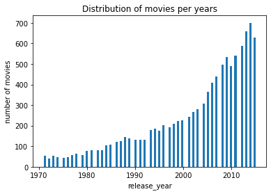

```python
plt.hist(data = df_clean_movies, x = 'release_year' , bins = 100)
plt.xlabel('release_year')
plt.ylabel('number of movies')
plt.title('Distribution of movies per years')
plt.show()
```

## (Relationship between revenue and budget)

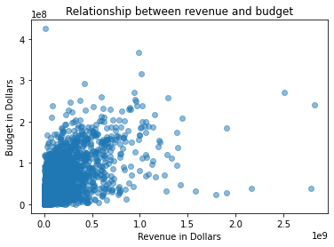

```python
# x-axis
plt.xlabel('Revenue in Dollars')
# y-axis
plt.ylabel('Budget in Dollars')
# Title of the histogram
plt.title('Relationship between revenue and budget')
plt.scatter(df_clean_movies['revenue_adj'], df_clean_movies['budget_adj'], alpha=0.5)
plt.show()
```

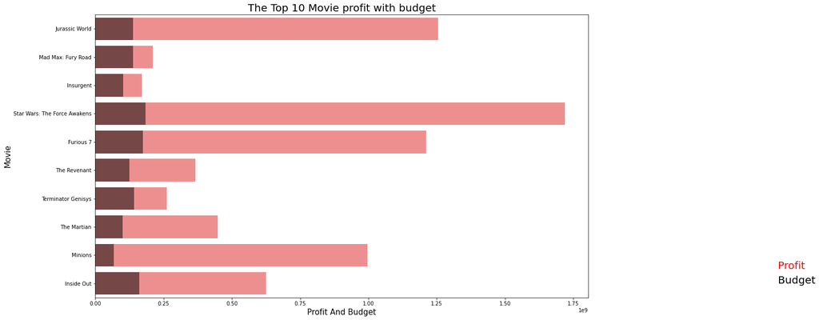

```python
#plot the first 10 Movie profit with budget
plt.figure(figsize = (17,10))
sb.barplot(x = "profit",y= "original_title", data=  df_clean_movies.head(10),color="red",alpha=0.5,Label="Profit")
sb.barplot(x = "budget_adj", y = "original_title",data= df_clean_movies.head(10),color= "black", alpha=0.5,label ="Budget")


plt.text(2500000000,8.5,"Profit",color="red",fontsize = 20 )
plt.text(2500000000,9,"Budget", color="black",  fontsize = 20 )
plt.xlabel("Profit And Budget",fontsize= 15)
plt.ylabel("Movie",fontsize= 15)
plt.title("The Top 10 Movie profit with budget",fontsize = 20)
```

## (Exploring the relationship between the avarge vote with profit and bugdet)

> i see the most of green area that repersent values 6 to 8 with the movies that achieve high profit.. there are un normal data that has voting with films that achieve low profit with too much budget.

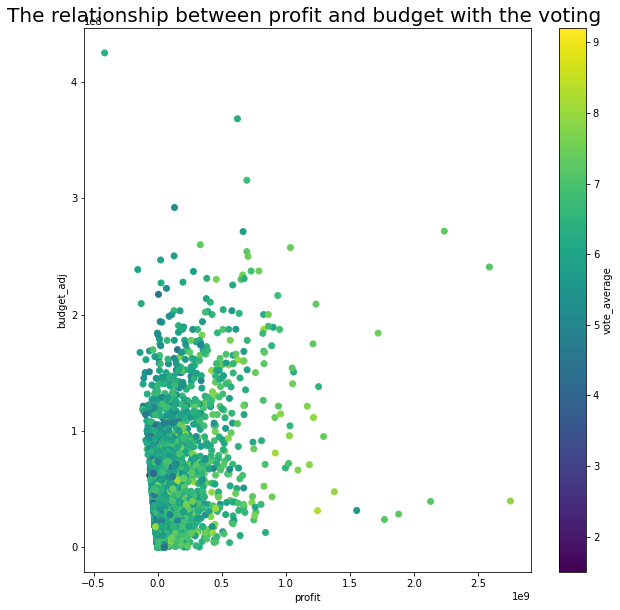

```python
plt.figure(figsize = [10,10])
plt.scatter(data = df_clean_movies, x = 'profit', y = 'budget_adj',
                c = 'vote_average')
plt.colorbar(label = 'vote_average')
plt.xlabel('profit')
plt.ylabel('budget_adj')
plt.title("The relationship between profit and budget with the voting ",fontsize = 20)
```